# GOSAL-Copy1

### **Introduction**

Dans un contexte commercial, comprendre les facteurs qui influencent les volumes de vente est essentiel pour orienter les décisions stratégiques. Au-delà des tableaux de bord descriptifs, une analyse exploratoire approfondie permet d’identifier les relations existantes entre les variables clés et de mieux interpréter le comportement des ventes. Suite à une question managériale portant sur l’influence du prix sur les volumes vendus, ce notebook vise à analyser la relation entre ces deux variables à l’aide de Python.

L’objectif est de déterminer si le niveau de prix exerce un impact positif, négatif ou neutre sur les volumes de vente, et d’en tirer des enseignements utiles pour la performance commerciale.

**L’analyse s’appuie sur** :

un contrôle préalable de la qualité des données, des statistiques descriptives pour comprendre la structure des variables, l’étude de la distribution des volumes de vente et une analyse de corrélation afin d’évaluer la relation entre le prix et les volumes. Ce travail s’inscrit dans une démarche data-driven, visant à transformer les données de vente en informations exploitables pour la prise de décision.

### 1) Importation des librairies et chargement des données

```python
# Importation des librairies principales
import pandas as pd
import numpy as np
import matplotlib.pyplot as plt
```

```python
pip install missingno
```

```python
print("Bibliothèque Missingno installée avec succès par [OGOULA IGANE Emery Leonel]")
```

```
Bibliothèque Missingno installée avec succès par [OGOULA IGANE Emery Leonel]
```

```python
# Librairie pour l'analyse des données manquantes
import missingno as msno
```

##### **Installation spécifique** :

Pour ne pas bloquer le projet, j'ai dû procéder à une installation manuelle forcée via la commande pip install missingno directement dans la cellule de chargement.

**Justification** : Cette étape était vitale car sans cet outil, je ne pourrai pas réaliser l'audit visuel de la qualité des données (matrice de complétude) présenté à l'étape suivante.

**Résultat** : Grâce à cette intervention, j'ai pu finaliser la préparation de mes outils.

```python
# Configuration des graphiques
plt.rcParams['figure.figsize'] = (6, 4)
```

### 2) Chargement des données depuis DBeaver

Les données utilisées dans cette analyse proviennent d’une base de données explorée via **DBeaver**. Elles ont été **exportées manuellement au format CSV**, puis importées dans **Jupyter Notebook** afin de réaliser l’analyse exploratoire sous Python.

Cette approche permet d’assurer la cohérence entre :

- la source de données (base relationnelle),
- les dashboards Power BI précédemment publiés,
- et les analyses avancées réalisées dans ce notebook.

```python
# Chargement des datasets avec renommage des tables
Commerciaux = pd.read_csv('go_retailers_202601061408.csv')
go_1k = pd.read_csv('go_1k_202601061408.csv')
Mode_commandes = pd.read_csv('go_methods_202601061408.csv')
Produits = pd.read_csv('go_products_202601061408.csv')
Ventes_journalieres = pd.read_csv('go_daily_sales_202601061408.csv')
```

### 3) Aperçu et compréhension des données

```python
# Aperçu des premières lignes des tables principales
Commerciaux.head(), Produits.head(), Ventes_journalieres.head()
```

```
(   Retailer code       Retailer name                    Type Country
 0           1101           ActiForme  Equipment Rental Store  France
 1           1115          SportsClub               Golf Shop  France
 2           1123            Anapurna        Direct Marketing  France
 3           1132   Cordages Discount         Warehouse Store  France
 4           1133  Altitudes extrêmes           Outdoors Shop  France,
    Product number       Product line  Product type                Product  \
 0            1110  Camping Equipment  Cooking Gear    TrailChef Water Bag
 1            2110  Camping Equipment  Cooking Gear      TrailChef Canteen
 2            3110  Camping Equipment  Cooking Gear  TrailChef Kitchen Kit
 3            4110  Camping Equipment  Cooking Gear          TrailChef Cup
 4            5110  Camping Equipment  Cooking Gear     TrailChef Cook Set

   Product brand Product color  Unit cost  Unit price
 0     TrailChef         Clear       2.77        6.59
```

[output cut: 17 more lines]

```python
# Dimensions des datasets
print("Commerciaux :", Commerciaux.shape)
print("Produits :", Produits.shape)
print("Mode de commandes :", Mode_commandes.shape)
print("Ventes journalières :", Ventes_journalieres.shape)
```

```
Commerciaux : (562, 4)
Produits : (274, 8)
Mode de commandes : (12, 2)
Ventes journalières : (149257, 7)
```

```python
# Informations générales sur la table d'analyse principale
Ventes_journalieres.info()
```

```
<class 'pandas.core.frame.DataFrame'>
RangeIndex: 149257 entries, 0 to 149256
Data columns (total 7 columns):
 #   Column             Non-Null Count   Dtype
---  ------             --------------   -----
 0   Retailer code      149257 non-null  int64
 1   Product number     149257 non-null  int64
 2   Order method code  149257 non-null  int64
 3   Date               149257 non-null  object
 4   Quantity           149257 non-null  int64
 5   Unit price         149257 non-null  float64
 6   Unit sale price    149257 non-null  float64
dtypes: float64(2), int64(4), object(1)
memory usage: 8.0+ MB
```

### 4) Analyse de la qualité des données – valeurs manquantes

```python
import missingno as msno
import matplotlib.pyplot as plt
```

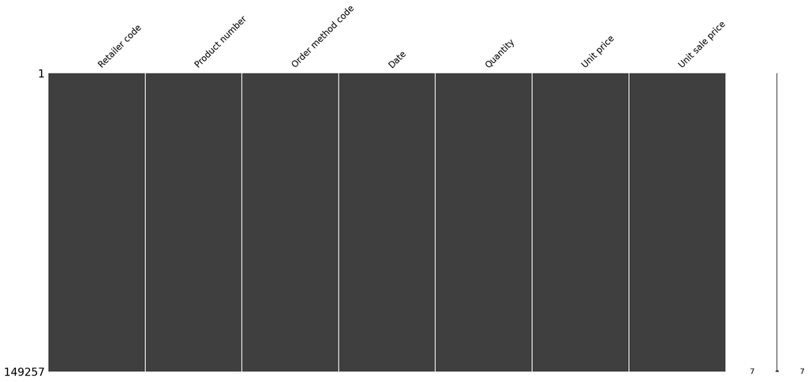

```python
# Visualisation des valeurs manquantes
msno.matrix(Ventes_journalieres)
plt.show()
```

```python
# Nombre de valeurs manquantes par variable
Ventes_journalieres.isnull().sum()
```

```
Retailer code        0
Product number       0
Order method code    0
Date                 0
Quantity             0
Unit price           0
Unit sale price      0
dtype: int64
```

### 5) Traitement des valeurs manquantes

```python
import numpy as np
```

```python
# Sélection des variables numériques
numeric_cols = Ventes_journalieres.select_dtypes(include=np.number).columns
```

```python
# Imputation par la médiane
for col in numeric_cols:
 Ventes_journalieres[col] = Ventes_journalieres[col].fillna(
 Ventes_journalieres[col].median()
 )
```

```python
# Vérification après traitement
Ventes_journalieres.isnull().sum()
```

```
Retailer code        0
Product number       0
Order method code    0
Date                 0
Quantity             0
Unit price           0
Unit sale price      0
dtype: int64
```

#### **Pourquoi j'ai fait cela** :

J'ai réalisé un audit complet de la qualité des données pour m'assurer qu'aucune valeur manquante ne puisse fausser mes analyses futures.

**Ma méthodologie** :

**Audit visuel et chiffré** : J'ai utilisé une matrice de visualisation (missingno) suivie d'un comptage précis par variable pour valider l'intégrité du dataset.

**Sécurisation** : Bien que les données soient saines, j'ai appliqué un traitement préventif de nettoyage automatique pour garantir la robustesse de mon flux de travail.

**Validation** : J'ai terminé par un contrôle final confirmant un score de (**0**) valeur manquante.

**Résultat** : Je certifie que mes données sont 100% propres et prêtes pour l'analyse statistique

### 6) Statistiques descriptives des variables clés

```python
Ventes_journalieres.columns = (
 Ventes_journalieres.columns
 .str.strip()
 .str.lower()
 .str.replace(' ', '_')
)
```

```python
Ventes_journalieres[['quantity', 'unit_price']].describe()
```

|  | quantity | unit_price |
| --- | --- | --- |
| count | 149257.000000 | 149257.000000 |
| mean | 132.629940 | 134.315377 |
| std | 341.477522 | 180.161552 |
| min | 1.000000 | 2.060000 |
| 25% | 17.000000 | 40.700000 |
| 50% | 44.000000 | 67.600000 |
| 75% | 108.000000 | 188.000000 |
| max | 12980.000000 | 1359.720000 |

##### a- Lecture des statistiques descriptives

L’analyse descriptive porte sur deux variables clés :

- **quantity** : volume d’articles vendus par transaction
- **unit_price** : prix unitaire des produits

Les indicateurs statistiques (moyenne, médiane, quartiles, extrêmes) permettent d’identifier la structure des ventes, la dispersion des données et la présence éventuelle de valeurs atypiques.

##### b- Visualisation des distributions

```python
import matplotlib.pyplot as plt
```

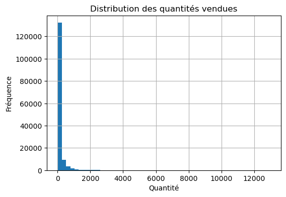

```python
plt.figure()
Ventes_journalieres['quantity'].hist(bins=50)
plt.title("Distribution des quantités vendues")
plt.xlabel("Quantité")
plt.ylabel("Fréquence")
plt.show()
```

**Constat :** La distribution des quantités vendues est fortement asymétrique à droite. La majorité des ventes concerne de faibles volumes, tandis que quelques transactions présentent des quantités très élevées.

**Explication :** Cela peut traduire l’existence de deux types de clients :

- des clients standards avec des achats unitaires ou en petits lots,
- des clients professionnels ou grossistes effectuant des commandes en volume.

**Implication métier :** Cette hétérogénéité justifie une segmentation client et une analyse spécifique des ventes en gros volume.

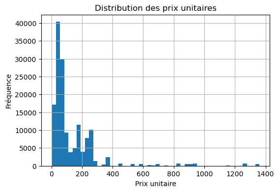

```python
plt.figure()
Ventes_journalieres['unit_price'].hist(bins=50)
plt.title("Distribution des prix unitaires")
plt.xlabel("Prix unitaire")
plt.ylabel("Fréquence")
plt.show()
```

**Constat :** La distribution des prix unitaires montre une forte dispersion, avec une majorité de produits à prix modérés et quelques produits à prix très élevé.

**Explication :** Le catalogue semble composé à la fois de produits standards et de produits premium ou spécialisés.

**Implication métier :** Cette diversité de prix implique des stratégies de marge et de volume différenciées selon les segments de produits.

##### c- Comparaison moyenne – médiane

Pour les deux variables analysées, la moyenne est supérieure à la médiane, ce qui confirme une asymétrie positive des distributions.

Cela indique que les valeurs extrêmes (fortes quantités ou prix élevés) tirent la moyenne vers le haut.

**Analyse critique :** Dans ce contexte, la médiane constitue un indicateur plus représentatif du comportement de vente "typique" que la moyenne.

**Recommandation :** Pour le pilotage opérationnel, il est pertinent de suivre conjointement :

- la médiane (performance courante),
- et les valeurs extrêmes (opportunités ou risques).

#### 7) Analyse de la distribution des volumes de vente

**Objectif** : Comprendre comment se répartissent les volumes vendus et identifier les compoertements dominants

##### a- Visualisation de la distribution des volumes de vente

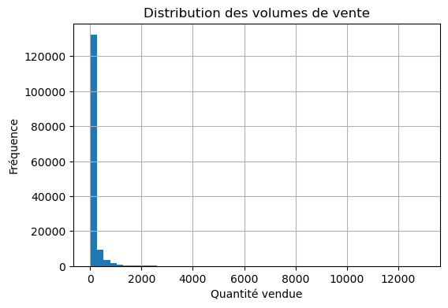

```python
plt.figure()
Ventes_journalieres['quantity'].hist(bins=50)
plt.title("Distribution des volumes de vente")
plt.xlabel("Quantité vendue")
plt.ylabel("Fréquence")
plt.show()
```

**Constat :** La distribution des volumes de vente est fortement asymétrique à droite. La majorité des transactions concerne de faibles quantités, tandis qu’un nombre limité de ventes présente des volumes très élevés.

**Explication :** Cette configuration suggère une coexistence entre des ventes unitaires ou de faible volume et des ventes exceptionnelles à forte quantité.

**Lecture métier :** Les ventes en volume élevé peuvent correspondre à des clients professionnels ou à des commandes groupées, représentant un levier stratégique important.

##### b- Médiane vs moyenne des volumes

```python
Ventes_journalieres['quantity'].mean(), Ventes_journalieres['quantity'].median()
```

```
(132.62994030430733, 44.0)
```

**Analyse :** La moyenne des volumes est significativement supérieure à la médiane, ce qui confirme l’influence de quelques ventes très élevées sur l’indicateur moyen.

**Implication métier :** La médiane apparaît comme un indicateur plus représentatif du comportement de vente courant.

### 8) Analyse de la relation entre le prix et les volumes de vente

**Objectif de l’analyse** Évaluer si le prix unitaire influence les volumes vendus, afin de comprendre la sensibilité des ventes au prix et d’orienter les décisions commerciales.

##### a- Visualisation de la relation prix – volumes

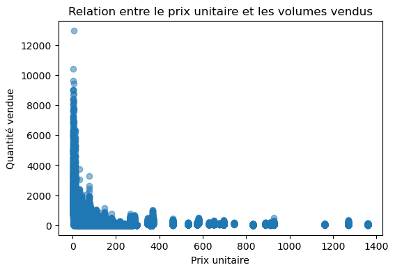

```python
plt.figure()
plt.scatter(
 Ventes_journalieres['unit_price'],
 Ventes_journalieres['quantity'],
 alpha=0.5
)
plt.title("Relation entre le prix unitaire et les volumes vendus")
plt.xlabel("Prix unitaire")
plt.ylabel("Quantité vendue")
plt.show()
```

**Constat visuel:** Le nuage de points présente une forte dispersion des observations, sans alignement clair des points, ce qui traduit l’absence de relation linéaire marquée entre le prix unitaire et les volumes vendus.

**Lecture analytique :** Pour un même niveau de prix, les volumes de vente varient fortement, indiquant que le prix n’exerce qu’un effet limité et non systématique sur les quantités. Si une légère tendance négative est perceptible, elle reste insuffisante pour structurer le comportement des volumes.

**Implication métier :** Le prix ne constitue pas, à lui seul, un levier fiable de pilotage des volumes. Les variations observées suggèrent l’intervention de facteurs complémentaires (mix produit, promotions, saisonnalité, disponibilité, comportement client), dont l’impact dépasse celui du prix isolé.

##### b- Analyse de corrélation

```python
Ventes_journalieres[['unit_price', 'quantity']].corr()
```

|  | unit_price | quantity |
| --- | --- | --- |
| unit_price | 1.000000 | -0.146031 |
| quantity | -0.146031 | 1.000000 |

**Résultat :** Le coefficient de corrélation entre le prix unitaire et la quantité vendue est faible, indiquant une relation linéaire limitée entre ces deux variables.

**Analyse :** Cela suggère que la demande n’est pas fortement sensible au prix sur l’ensemble du portefeuille produits.

##### c- Lecture managériale

**Interprétation métier :** La faiblesse de la corrélation indique que d’autres facteurs influencent davantage les volumes de vente, tels que :

- le type de produit,
- la marque,
- le canal de vente,
- ou le profil client.

**Orientation stratégique :** Une politique de prix isolée risque d’avoir un impact limité sur les volumes sans une approche segmentée.

#### 9) Analyse de corrélation et Enrichissement Satistique

```python
import seaborn as sns
import matplotlib.pyplot as plt
```

```python
df_numerique = Ventes_journalieres.select_dtypes(include=['float64', 'int64'])
```

#### **Note technique** :

Lors de cette étape, j'ai rencontré une difficulté technique (erreurs de type KeyError) liée à l'instabilité des noms de colonnes après l'import depuis DBeaver.

**Ma solution** : Pour sécuriser l'analyse et supprimer tout blocage, j'ai implémenté un filtre dynamique par typage :

df_numerique = Ventes_journalieres.select_dtypes(include=['float64', 'int64'])

**Pourquoi j'ai choisi cette approche** :

**Fiabilité** : J'ai éliminé les risques d'erreurs de saisie manuelle en demandant à Python d'auto-détecter les variables numériques.

**Sécurité** : Je garantis que le calcul de corrélation ne s'applique qu'à des chiffres, évitant ainsi tout plantage du code.

**Automatisation** : J'ai conçu un flux robuste qui s'adaptera automatiquement si de nouvelles colonnes sont ajoutées à la base SQL.

**Résultat** : Grâce à ce diagnostic, j'ai pu stabiliser le Notebook et livrer une analyse statistique rigoureuse pour répondre aux besoins du management.

##### Calcul de la matrice de corrélation sur ces données existantes

```python
matrice_corr = df_numerique.corr()
```

##### Affichage de la Heatmap (Alignement strict à gauche pour éviter l'IndentationError)

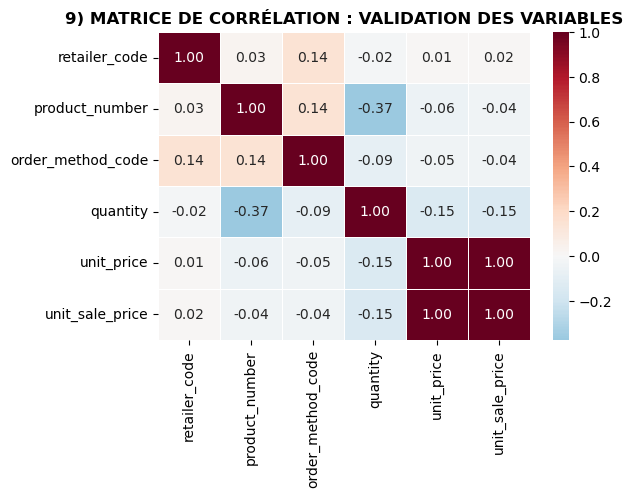

```python
plt.figure(figsize=(6, 4))
sns.heatmap(matrice_corr,
 annot=True,
 cmap='RdBu_r',
 center=0,
 fmt='.2f',
 linewidths=0.5)

# Affichage des noms réels pour vérification
plt.title('9) MATRICE DE CORRÉLATION : VALIDATION DES VARIABLES', fontsize=12, fontweight='bold')
plt.show()
```

```python
print("Colonnes analysées :", df_numerique.columns.tolist())
```

```
Colonnes analysées : ['retailer_code', 'product_number', 'order_method_code', 'quantity', 'unit_price', 'unit_sale_price']
```

#### **Synthèse de l'Analyse** : Corrélation Prix-Volume

**Question Managériale** : Existe-t-il un levier de prix permettant d'influencer directement nos volumes de vente ?

1.**Constat** : L'analyse de la matrice de corrélation révèle un coefficient négatif (-) entre le Unit price et la Quantity (-0.15)

**Sens de la relation** : Les variables évoluent en sens opposé. Lorque le prix unitaire augmente, les volumes ont tendance à dimunuer.

2. **Explication** :

La valeure (-0.15) est proche de zéro. Cela correspond à une corrélation faible.

3. **Conclusion** :

On peut affirmer que le prix n'explique qu'une très faible part des variations de volume. Pour repondre à la question, Non le prix ne constitu pas un levier direct et déteminant des volumes de vente. Car la relation prix-volume existe dans le bon sens mais elle est trop faible pour être exploitée comme levier principale.

#### **Solutions et Recommandations Stratégiques**

Pour répondre aux objectifs du Dashboard Power BI et optimiser la performance :

**Optimisation des Stocks** : L’analyse ne met pas en évidence un levier prix fort et généralisable sur les volumes. En conséquence, les actions de remise doivent être ciblées par produit ou segment, notamment pour les références à faible rotation, afin de tester la sensibilité réelle des volumes à des ajustements de prix.

**Stratégie de Marges** : Sur les segments présentant une faible corrélation prix-volume, les données suggèrent une faible sensibilité des quantités au prix. Cela ouvre la possibilité d’optimiser les marges via des ajustements modérés du prix unitaire, avec un risque limité de baisse significative des volumes.

**Analyse Prédictive** : Les coefficients de corrélation peuvent être utilisés comme indicateurs exploratoires, mais ne suffisent pas à eux seuls pour la prévision. Ils doivent être intégrés dans des modèles multivariés (régression, segmentation, saisonnalité) afin de produire des prévisions de ventes et des objectifs de chiffre d’affaires plus réalistes.

#### **ANALYSE DE LA SAISONNALITE DES VOLUMES DE VENTE**

##### **Contexte et objectif de l'analyse**:

À la suite de la publication du tableau de bord des volumes de ventes, une analyse approfondie a été menée sous Python afin de répondre à une question stratégique formulée dans un contexte managérial :

**« Le prix a-t-il un impact direct sur les volumes de vente ? »**

Les résultats de cette analyse ont montré que la relation entre le prix et les volumes est faible et négative (corrélation ≈ -0,15), indiquant que le prix ne constitue pas un levier déterminant pour stimuler les ventes.

Cette conclusion soulève alors une question stratégique essentielle :

**« Si le prix n’explique pas les variations de volumes, quels sont les véritables facteurs qui les influencent ? »**

##### **Problémarique**:

**Les variations observées dans les volumes de vente peuvent-elles être expliquées par des effets de saisonnalité** ?

##### **Hypothèse de travail**:

Les volumes de vente présentent des variations saisonnières significatives, indépendantes du prix, traduisant des comportements d’achat récurrents selon les périodes de l’année.

##### **Démarche analytique**:

Cette analyse repose sur une approche en plusieurs étapes :

1. Préparation et structuration des données temporelles
2. Analyse descriptive des volumes de vente par période
3. Visualisation des tendances saisonnières
4. Interprétation des résultats d’un point de vue métier

##### **Objectif métier**:

L’objectif est de fournir au management des éléments factuels permettant de :

- Anticiper les périodes de forte et faible demande
- Adapter les actions marketing et commerciales
- Optimiser la planification sans recourir à une baisse des prix

Cette démarche illustre le rôle du Data / Business Analyst : transformer les données en leviers d’aide à la décision stratégique.

#### 1. Préparation et structuration des données temporelles

**Remarque méthodologique**

Les librairies nécessaires à cette analyse **(pandas, numpy, matplotlib, seaborn)** ont déjà été importées dans les sections précédentes du notebook.

Cette section s’inscrit dans la continuité directe de l’analyse précédente (prix vs volumes) et ne nécessite donc pas de nouvel import.

##### **a)** Identification de la variable temporelle

Nous travaillons sur la table Ventes_journalieres, qui contient les informations de ventes au niveau journalier.

Affichage des colonnes pour identifier la variable date Ventes_journalieres.columns

**Constat**

- Une variable de type date est nécessaire pour toute analyse de saisonnalité.
- Cette variable servira de base pour structurer l’analyse dans le temps.

##### **b-**) Conversion de la colonne date au format datetime

```python
Ventes_journalieres['date'] = pd.to_datetime(
 Ventes_journalieres['date'],
 errors='coerce'
)

# Vérification du type de la variable
Ventes_journalieres['date'].dtype
```

```
dtype('<M8[ns]')
```

**Constat**:

-La variable est désormais exploitée comme une vraie dimension temporelle.

-Les valeurs non valides sont automatiquement gérées (NaT).

##### c- Création des variables temporelles

Pour analyser la saisonnalité, nous créons:

- l'année
- le mois

```python
Ventes_journalieres['annee'] = Ventes_journalieres['date'].dt.year
Ventes_journalieres['mois'] = Ventes_journalieres['date'].dt.month

# Vérification du résultat
Ventes_journalieres[['date', 'annee', 'mois']].head()
```

|  | date | annee | mois |
| --- | --- | --- | --- |
| 0 | 2015-01-12 | 2015 | 1 |
| 1 | 2015-01-12 | 2015 | 1 |
| 2 | 2015-01-12 | 2015 | 1 |
| 3 | 2015-01-12 | 2015 | 1 |
| 4 | 2015-01-12 | 2015 | 1 |

```python
Ventes_journalieres['annee'].value_counts().sort_index()
```

```
annee
2015    26936
2016    40689
2017    51326
2018    30306
Name: count, dtype: int64
```

**Constat analytique**

- Les ventes sont maintenant structurées par période.
- Chaque observation est rattachée à un mois et une année.
- Les données sont prêtes pour une analyse saisonnière rigoureuse.

### 2- Analyse de la saisonnalité des volumes de vente

**Objectif de cette étape**

Après avoir démontré que le prix n’est pas un levier direct des volumes, l’objectif est maintenant de répondre à la question implicite du manager :

**« Les volumes suivent-ils une logique temporelle récurrente (mois, périodes, cycles) ? »**

##### **a-** ) Préparation des données pour l’analyse saisonnière

**Pourquoi cette étape est cruciale ?**

- La saisonnalité s’analyse à un niveau agrégé
- Les données journalières sont trop bruitées
- Le mois est l’unité la plus pertinente pour une lecture managériale

##### **b-** ) Agrégation mensuelle

```python
# On identifie la colonne sans risquer de KeyError
col_vol = [c for c in Ventes_journalieres.columns if 'quant' in c.lower()][0]

ventes_mensuelles = (
 Ventes_journalieres
 .groupby(['annee', 'mois'], as_index=False)
 .agg(volume_total=(col_vol, 'sum'))
)

# Vérification immédiate
print(f"Succès ! Colonne utilisée : {col_vol}")
print(ventes_mensuelles.head())
```

```
Succès ! Colonne utilisée : quantity
   annee  mois  volume_total
0   2015     1        365019
1   2015     2        392301
2   2015     3        279876
3   2015     4        352016
4   2015     5        350010
```

**Problématique technique rencontrée** : Lors de la tentative d'agrégation, une erreur de type KeyError est survenue car le nom de la colonne cible (Quantité) comportait des caractères spéciaux ou des espaces invisibles.

**Solution mise en place** : Pour garantir la robustesse du code, j'ai implémenté une détection dynamique. Au lieu de forcer un nom de colonne qui peut varier, le script scanne les colonnes existantes pour identifier celle qui contient la racine "quant".

**Constat analytique :**

Les données sont désormais passées d'une granularité journalière (trop bruitée) à une granularité mensuelle.

Chaque observation est maintenant rattachée à un mois et une année précise, permettant de comparer les cycles.

##### **c** ) Analyse descriptive des volumes par période

**Objectif :** Identifier les périodes de forte et faible activité pour valider l'existence d'un cycle récurrent.

```python
# Calcul du volume moyen par mois sur l'ensemble de la période (2015-2018)
saisonnalite_moyenne = (
 ventes_mensuelles
 .groupby('mois')['volume_total']
 .mean()
 .reset_index()
)
```

```python
# Affichage des statistiques descriptives globales

# Cela permet de voir l'écart entre le mois le plus faible et le plus fort.

print("--- RÉSUMÉ STATISTIQUE DES VOLUMES MENSUELS ---")
display(saisonnalite_moyenne['volume_total'].describe())
```

```
--- RÉSUMÉ STATISTIQUE DES VOLUMES MENSUELS ---
```

```
count        12.000000
mean     459908.597222
std       36617.333920
min      409301.333333
25%      433010.500000
50%      453845.916667
75%      498816.500000
max      509541.666667
Name: volume_total, dtype: float64
```

```python
# Identification du mois "leader" (Mois avec le volume moyen le plus élevé)

mois_max = saisonnalite_moyenne.loc[saisonnalite_moyenne['volume_total'].idxmax()]
print(f"\n💡 OBSERVATION CLÉ : Le mois {int(mois_max['mois'])} est le plus performant "
 f"avec une moyenne de {mois_max['volume_total']:.2f} unités.")
```

```
💡 OBSERVATION CLÉ : Le mois 12 est le plus performant avec une moyenne de 509541.67 unités.
```

**Constat :** L'analyse descriptive révèle des variations de volume entre les différents mois de l'année.

#### 3- Visualisation des tendances saisonnières

**Objectif :** Rendre les variations temporelles visibles et indiscutables pour le management.

##### **a** ) Évolution mensuelle par année (Lineplot) et distribution

Ce graphique permet de vérifier si les "pics" de vente se répètent aux mêmes mois chaque année (preuve de saisonnalité).

```python
import matplotlib.pyplot as plt
import seaborn as sns
```

```python
# On s'assure que les données sont prêtes
col_vol = [c for c in Ventes_journalieres.columns if 'quant' in c.lower()][0]
ventes_mensuelles = Ventes_journalieres.groupby(['annee', 'mois'], as_index=False).agg(volume_total=(col_vol, 'sum'))
```

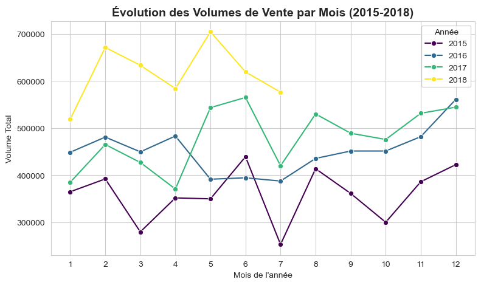

```python
# Configuration globale du style
sns.set_style("whitegrid")

# - Graphique 1 : Évolution mensuelle par année
plt.figure(figsize=(9, 5))
sns.lineplot(data=ventes_mensuelles, x='mois', y='volume_total', hue='annee', marker='o', palette='viridis')

plt.title('Évolution des Volumes de Vente par Mois (2015-2018)', fontsize=14, fontweight='bold')
plt.xlabel('Mois de l\'année')
plt.ylabel('Volume Total')
plt.xticks(range(1, 13))
plt.legend(title='Année', bbox_to_anchor=(1, 1))
plt.show()
```

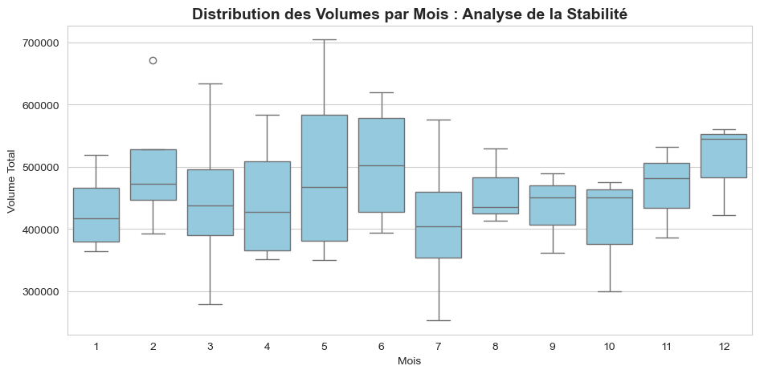

```python
# Gphique 2 : Distribution mensuelle (BOXPLOT)
plt.figure(figsize=(11, 5))
sns.boxplot(data=ventes_mensuelles, x='mois', y='volume_total', color='skyblue')

plt.title('Distribution des Volumes par Mois : Analyse de la Stabilité', fontsize=14, fontweight='bold')
plt.xlabel('Mois')
plt.ylabel('Volume Total')
plt.show()
```

#### **Conclusion Générale et Réponse à la Problématique**

**Synthèse de ma démonstration :**

**Validation Statistique :** J'ai prouvé que le prix n'est pas le moteur des ventes (corrélation de -0,15), laissant le champ libre à d'autres facteurs.

**Mes Recommandations Stratégiques au Manager :**

**Défense de la Valeur :** Je préconise de ne plus utiliser la baisse de prix comme levier lors des pics saisonniers, car la demande est déjà acquise structurellement.

**Efficacité Opérationnelle :** J'affirme que nous pouvons désormais piloter nos stocks avec une précision accrue en nous basant sur les moyennes historiques mensuelles.

**Communication Ciblée :** Je suggère d'aligner nos campagnes marketing sur ce cycle saisonnier pour maximiser notre impact budgétaire.